# Rintrodev

**Introduction: R and Jupyter**

Welcome to *R*, on HCC/Binder, through Jupyter.

*"R is a free software environment for statistical computing and graphics"*  
[www.r-project.org](https://www.r-project.org/)  
"The Jupyter Notebook is an open-source web application that allows you to create and share documents that contain live code,  
equations, visualizations and narrative text"  
[www.jupyter.org](https://jupyter.org/)

**Jupyter Notebook**  
Segregated into a kernel (execute code) and dashboard & editor (interface), Jupyter permits mixing real-time coding with interactive rich-text ouputs in self-contained *.ipynb(JSON)* documents (local or remote).  
Kernels include Julia, Python, R, MATLAB/Octave, etc.  
Interact with input cells (code, markdown, etc) that exhibit an order and mode - insert, edit, run.

`$ jupyter notebook`

**R**  
Starting *R* loads an interpreter and creates a workspace/environment to store values and perform commands.  
Interact with terminal directly or indirectly through scripts (*.R* extension).

```r
#R - load & open (terminal)
#module load R.3.4
#R
```

```r
#get (/set) current/working directory
getwd()
#setwd('/home/XXX');

#list.files(); #RUN BELOW, INSERT NEW CELL ...
```

[output not shown]

```r
list.files()
```

[output not shown]

**#Tip 1.** a popular GUI alternative is R Studio.

**Calculations**  
Mathematical calculations - elements & arrays (/vectors).  
Example operators: `+`, `-`, `*`, `/`, `^`.

```r
(20+20)/5
```

8

```r
c(1,2,3,4) * c(1,2,3,4)
```

1. 1

2. 4

3. 9

4. 16

```r
#81^(1/2)
sqrt(81); #built-in code (base functions)
```

9

**Functions**  
Perform procedures - Input to Output with options/arguments (*round brackets*).  
Combining elements `c()` is one of the simplest base functions.  
With no defined arguments, functions when called will resort to default values found in documentation (? / help).

```r
#nested example (runif = generate random number)
sort( runif(10, min=0, max=1) , decreasing=FALSE, index.return=FALSE)
```

1. 0.139983697095886

2. 0.141913911094889

3. 0.211340273730457

4. 0.225717290770262

5. 0.437411859631538

6. 0.479913854040205

7. 0.720700970385224

8. 0.890207114629447

9. 0.954978888388723

10. 0.965964139439166

```r
#check documentation (usage, arguments, details, examples, etc)
?sort
```

```r
calculate_SE <- function(x){
    #define function to calculate standard error ({body - local env})
    return( sqrt(var(x) / length(x)) )
}

calculate_SE( c(10.4, 5.6, 3.1, 6.4, 21.7) ); #run function
```

3.28185922915655

**#Tip 2.** source("Rcode.R").

**Assignment**  
Commands `<<-->-` OR `=` assigns and stores outputs/results as well as functions to memory (case-sensitive).  
*R* operates on named data structures, that is, sets of ordered entities.  
Example vectors: numeric (double, integer, complex), logical, character.

```r
x <- c(10.4, 5.6, 3.1, 6.4, 21.7);
#x = c(10.4, 5.6, 3.1, 6.4, 21.7);

typeof(x)
x
```

'double'

1. 10.4

2. 5.6

3. 3.1

4. 6.4

5. 21.7

```r
y <- c("test", "control", "control", "control", "test");
#y = c("test", "control", "control", "control", "test");

typeof(y)
y
```

'character'

1. 'test'

2. 'control'

3. 'control'

4. 'control'

5. 'test'

**#Tip 3.** quotation characters, double (") and single ('), are exchangeable.

**Structures**  
While vectors are the most important type of object/structure/variable in *R*, others exist each with intrinsic attributes (mode and length). Conversion between types is relatively intuitive - `as.character`, `as.numeric`, `as.data.frame`.  
Examples: matrices, lists, dataframes.

```r
set.seed(5); #define seed to reproduce random results

#matrices - visualize toy example
X = matrix( runif(20, min=0, max=10) , nrow=4, ncol=5, byrow=FALSE);

dim(X)
X
```

1. 4

2. 5

| 2.002145 | 1.046501 | 9.565001 | 3.184040 | 3.875257 |
| --- | --- | --- | --- | --- |
| 6.852186 | 7.010575 | 1.104530 | 5.591728 | 8.878698 |
| 9.168758 | 5.279600 | 2.732849 | 2.625931 | 5.549226 |
| 2.843995 | 8.079352 | 4.905132 | 2.018752 | 8.421794 |

**Indexing**  
Access parts of a dataset, rows then columns (*square brackets*), starting with 1, can be coded multiple ways.  
Wildcard `:` generates a regular sequence from start to stop (by 1).

```r
X[2, 4]
```

5.59172826586291

```r
t(X)[2, 4]; #transpose (rows to columns, columns to rows)
```

8.07935200864449

```r
X[c(2,4), 4] = c(0,10); #replace elements
X
```

| 2.002145 | 1.046501 | 9.565001 | 3.184040 | 3.875257 |
| --- | --- | --- | --- | --- |
| 6.852186 | 7.010575 | 1.104530 | 0.000000 | 8.878698 |
| 9.168758 | 5.279600 | 2.732849 | 2.625931 | 5.549226 |
| 2.843995 | 8.079352 | 4.905132 | 10.000000 | 8.421794 |

```r
X[1:3, 2:3]

cbind(X[1:3, 2], X[1:3, 3]); #concatenate columns

rbind(X[1, 2:3], X[2, 2:3], X[3, 2:3]); #concatenate rows
```

| 1.046501 | 9.565001 |
| --- | --- |
| 7.010575 | 1.104530 |
| 5.279600 | 2.732849 |

| 1.046501 | 9.565001 |
| --- | --- |
| 7.010575 | 1.104530 |
| 5.279600 | 2.732849 |

| 1.046501 | 9.565001 |
| --- | --- |
| 7.010575 | 1.104530 |
| 5.279600 | 2.732849 |

**Conditions**  
Checks that control the flow of actions/execution (if / else).  
Comparsion: lesser than (`<`), greater than (`>`), equal (`==`), different (`!=`).  
Logical/Boolean: AND (`&`) if both *true*, OR (`|`) if either *true*, NOT (`!`) converts *true* to *false*.

```r
X[X > 5]; #output - free from dimensions (byrow=FALSE)
X
```

1. 6.85218595666811

2. 9.1687577450648

3. 7.01057459227741

4. 5.27959984261543

5. 8.07935200864449

6. 9.565001251176

7. 10

8. 8.87869771569967

9. 5.5492255394347

10. 8.42179385246709

| 2.002145 | 1.046501 | 9.565001 | 3.184040 | 3.875257 |
| --- | --- | --- | --- | --- |
| 6.852186 | 7.010575 | 1.104530 | 0.000000 | 8.878698 |
| 9.168758 | 5.279600 | 2.732849 | 2.625931 | 5.549226 |
| 2.843995 | 8.079352 | 4.905132 | 10.000000 | 8.421794 |

```r
X[X >= 6 & X <= 7]; #across whole matrix
X[1, X[1, ] >= 6 & X[1, ] <= 7]; #only first row
```

6.85218595666811

```r
if (dim(X)[1] != 4) {
    print("check - dimensions don't match"); #first check cond.1, TRUE do something
} else if (dim(X)[2] != 5) {
    print("check - dimensions don't match"); #FALSE then try cond.2, TRUE now do something different
} else {
    print("good - dimensions match"); #FALSE again, do something else
}
```

```
[1] "good - dimensions match"
```

```r
y[y == "test"]
```

1. 'test'

2. 'test'

**#Tip 4.** use tab for auto-completion & arrow keys for command history.

```r
#CHECK-IN POINT
#EXERCISE - create new variable, randlett, of 2000 randomly sampled ?LETTERS (hint), and count occurrences (a-z).

#EXERCISE - define new function, roundndivide, to take two numeric/double inputs (x1 and x2), rounds to nearest integers,
#divides integers, and returns logical output (TRUE/FALSE) if absolute of result is greater than 1.
```

**Iterations**  
Scalar loops, element by element, can be used to repeat procedures (for / while).  
Vectorization, all elements at once, however is faster and scalable - `apply` (array), `lapply` (list), `sapply` (vector) - reducing redundancies/overhead,  
using Fortan / C / C++ routines, and so on.

```r
#initiate variable of NA (missing values) to fill during loop (preallocate - growing objects inefficient)
colMean = rep(NA, times=dim(X)[2]);

for (i in 1:dim(X)[2]){
    #variable i in sequence start:end
    print(i)
    colMean[i] = mean(X[ ,i])
    #break;#next
}

colMean
```

```
[1] 1
[1] 2
[1] 3
[1] 4
[1] 5
```

1. 5.21677070006263

2. 5.35400693072006

3. 4.5768782380037

4. 3.95249289344065

5. 6.68124364456162

```r
colMean = apply(X, 2, mean); #column by column
colMean

#colMeans(X)
```

1. 5.21677070006263

2. 5.35400693072006

3. 4.5768782380037

4. 3.95249289344065

5. 6.68124364456162

```r
rowSE = apply(X, 1, calculate_SE); #row by row
rowSE
```

1. 1.48902280369221

2. 1.76671496729455

3. 1.19392504007638

4. 1.2987481128253

**#Tip 5.** check system.time().

**Packages**  
Executable codes/functions developed by the community are organised and shared online in resposities - these can be retrieved/downloaded (source (compile) vs bundled (compressed) vs binary (pre-built)), structured into directories (libraries) and loaded into memory to use. Packages will often require other packages - dependencies.  
Repositories: CRAN (official network), Bioconductor (bioinformatic specific), GitHub.  
Packages: `Tidyverse`, `Shiny`, `dada2`, `phyloseq`, `MetaboAnalystR`, `lme4`.

```r
#lapply(.libPaths(), dir)
lapply(.libPaths(), list.files) #print available/downloaded packages
```

1. 1. 'assertthat'

   2. 'backports'

   3. 'base'

   4. 'base64enc'

   5. 'BH'

   6. 'bindr'

   7. 'bindrcpp'

   8. 'bitops'

   9. 'boot'

   10. 'broom'

   11. 'car'

   12. 'caret'

   13. 'caTools'

   14. 'cellranger'

   15. 'class'

   16. 'cluster'

   17. 'codetools'

   18. 'colorspace'

   19. 'compiler'

   20. 'crayon'

   21. 'curl'

   22. 'data.table'

   23. 'datasets'

   24. 'DBI'

   25. 'dichromat'

   26. 'digest'

   27. 'dplyr'

   28. 'evaluate'

   29. 'forcats'

   30. 'foreach'

   31. 'foreign'

   32. 'formatR'

   33. 'ggplot2'

   34. 'gistr'

   35. 'glmnet'

   36. 'glue'

   37. 'graphics'

   38. 'grDevices'

   39. 'grid'

   40. 'gtable'

   41. 'haven'

   42. 'hexbin'

   43. 'highr'

   44. 'hms'

   45. 'htmltools'

   46. 'htmlwidgets'

   47. 'httpuv'

   48. 'httr'

   49. 'IRdisplay'

   50. 'IRkernel'

   51. 'iterators'

   52. 'jsonlite'

   53. 'KernSmooth'

   54. 'knitr'

   55. 'labeling'

   56. 'lattice'

   57. 'lazyeval'

   58. 'lme4'

   59. 'lubridate'

   60. 'magrittr'

   61. 'maps'

   62. 'markdown'

   63. 'MASS'

   64. 'Matrix'

   65. 'MatrixModels'

   66. 'methods'

   67. 'mgcv'

   68. 'mime'

   69. 'minqa'

   70. 'mnormt'

   71. 'ModelMetrics'

   72. 'modelr'

   73. 'munsell'

   74. 'nlme'

   75. 'nloptr'

   76. 'nnet'

   77. 'openssl'

   78. 'parallel'

   79. 'pbdZMQ'

   80. 'pbkrtest'

   81. 'pkgconfig'

   82. 'plogr'

   83. 'plyr'

   84. 'pryr'

   85. 'psych'

   86. 'purrr'

   87. 'quantmod'

   88. 'quantreg'

   89. 'R6'

   90. 'randomForest'

   91. 'rbokeh'

   92. 'RColorBrewer'

   93. 'Rcpp'

   94. 'RcppEigen'

   95. 'readr'

   96. 'readxl'

   97. 'rematch'

   98. 'repr'

   99. 'reshape2'

   100. 'rlang'

   101. 'rmarkdown'

   102. 'rpart'

   103. 'rprojroot'

   104. 'rvest'

   105. 'scales'

   106. 'selectr'

   107. 'shiny'

   108. 'sourcetools'

   109. 'SparseM'

   110. 'spatial'

   111. 'splines'

   112. 'stats'

   113. 'stats4'

   114. 'stringi'

   115. 'stringr'

   116. 'survival'

   117. 'tcltk'

   118. 'tibble'

   119. 'tidyr'

   120. 'tidyverse'

   121. 'tools'

   122. 'translations'

   123. 'TTR'

   124. 'utils'

   125. 'uuid'

   126. 'xml2'

   127. 'xtable'

   128. 'xts'

   129. 'yaml'

   130. 'zoo'

```r
#install.packages('ggplot2')
library(ggplot2)

#source("https://bioconductor.org/biocLite.R");biocLite()
#install.packages('devtools');devtools::install_github()
```

```r
#packages can contain data also
data(package = "ggplot2")
```

```r
#data("mpg", package = "ggplot2")
data("midwest", package = "ggplot2"); #call dataset (midwest demographics) into memory/env

class(midwest)
dim(midwest)

#?detach()
#?remove.packages()
```

1. 'tbl_df'

2. 'tbl'

3. 'data.frame'

1. 437

2. 28

**Dataframes**  
A special list of vectors of equal length that suggests an implicit relationship between elements.  
Without such restrictions, variable type would default to a basic list.

```r
head(midwest)
```

| PID | county | state | area | poptotal | popdensity | popwhite | popblack | popamerindian | popasian | ⋯ | percollege | percprof | poppovertyknown | percpovertyknown | percbelowpoverty | percchildbelowpovert | percadultpoverty | percelderlypoverty | inmetro | category |
| --- | --- | --- | --- | --- | --- | --- | --- | --- | --- | --- | --- | --- | --- | --- | --- | --- | --- | --- | --- | --- |
| 561 | ADAMS | IL | 0.052 | 66090 | 1270.9615 | 63917 | 1702 | 98 | 249 | ⋯ | 19.63139 | 4.355859 | 63628 | 96.27478 | 13.151443 | 18.01172 | 11.009776 | 12.443812 | 0 | AAR |
| 562 | ALEXANDER | IL | 0.014 | 10626 | 759.0000 | 7054 | 3496 | 19 | 48 | ⋯ | 11.24331 | 2.870315 | 10529 | 99.08714 | 32.244278 | 45.82651 | 27.385647 | 25.228976 | 0 | LHR |
| 563 | BOND | IL | 0.022 | 14991 | 681.4091 | 14477 | 429 | 35 | 16 | ⋯ | 17.03382 | 4.488572 | 14235 | 94.95697 | 12.068844 | 14.03606 | 10.852090 | 12.697410 | 0 | AAR |
| 564 | BOONE | IL | 0.017 | 30806 | 1812.1176 | 29344 | 127 | 46 | 150 | ⋯ | 17.27895 | 4.197800 | 30337 | 98.47757 | 7.209019 | 11.17954 | 5.536013 | 6.217047 | 1 | ALU |
| 565 | BROWN | IL | 0.018 | 5836 | 324.2222 | 5264 | 547 | 14 | 5 | ⋯ | 14.47600 | 3.367680 | 4815 | 82.50514 | 13.520249 | 13.02289 | 11.143211 | 19.200000 | 0 | AAR |
| 566 | BUREAU | IL | 0.050 | 35688 | 713.7600 | 35157 | 50 | 65 | 195 | ⋯ | 18.90462 | 3.275891 | 35107 | 98.37200 | 10.399635 | 14.15882 | 8.179287 | 11.008586 | 0 | AAR |

```r
print(colnames(midwest))
#rownames(midwest)
```

```
 [1] "PID"                  "county"               "state"
 [4] "area"                 "poptotal"             "popdensity"
 [7] "popwhite"             "popblack"             "popamerindian"
[10] "popasian"             "popother"             "percwhite"
[13] "percblack"            "percamerindan"        "percasian"
[16] "percother"            "popadults"            "perchsd"
[19] "percollege"           "percprof"             "poppovertyknown"
[22] "percpovertyknown"     "percbelowpoverty"     "percchildbelowpovert"
[25] "percadultpoverty"     "percelderlypoverty"   "inmetro"
[28] "category"
```

```r
#get unique 'states' (with example indexing)
unique(midwest$state)
unique(midwest[ ,"state"])
unique(midwest[ ,3])
```

1. 'IL'

2. 'IN'

3. 'MI'

4. 'OH'

5. 'WI'

| state |
| --- |
| IL |
| IN |
| MI |
| OH |
| WI |

| state |
| --- |
| IL |
| IN |
| MI |
| OH |
| WI |

**#Tip 6.** tibbles are modern dataframes with subtleties (printing & subsetting).

**Manipulation**  
Packages `dplyr` and `tidyr` are popular methods to wield (*select, exclude, add*) dataframes - rows/columns.  
Base functions exist also and again can be coded multiple ways.

```r
#base method (logical TRUE/FALSE)
datOH = midwest[midwest$state=="OH", ];head(datOH)
#datOHc = midwest[midwest$state=="OH", 2];head(datOHc)
```

| PID | county | state | area | poptotal | popdensity | popwhite | popblack | popamerindian | popasian | ⋯ | percollege | percprof | poppovertyknown | percpovertyknown | percbelowpoverty | percchildbelowpovert | percadultpoverty | percelderlypoverty | inmetro | category |
| --- | --- | --- | --- | --- | --- | --- | --- | --- | --- | --- | --- | --- | --- | --- | --- | --- | --- | --- | --- | --- |
| 2009 | ADAMS | OH | 0.035 | 25371 | 724.8857 | 25212 | 47 | 67 | 30 | ⋯ | 8.74173 | 2.158135 | 25028 | 98.64806 | 28.52805 | 35.024685 | 25.752259 | 26.180060 | 0 | LHR |
| 2010 | ALLEN | OH | 0.024 | 109755 | 4573.1250 | 96177 | 12313 | 202 | 572 | ⋯ | 17.36606 | 3.479308 | 104543 | 95.25124 | 12.66656 | 17.857986 | 10.567921 | 10.744423 | 1 | AAU |
| 2011 | ASHLAND | OH | 0.025 | 47507 | 1900.2800 | 46686 | 460 | 49 | 271 | ⋯ | 17.26695 | 4.159440 | 45486 | 95.74589 | 11.34415 | 17.228991 | 9.159434 | 8.674284 | 0 | AAR |
| 2012 | ASHTABULA | OH | 0.041 | 99821 | 2434.6585 | 95465 | 3138 | 196 | 350 | ⋯ | 13.24354 | 2.883320 | 97541 | 97.71591 | 16.11733 | 23.818625 | 13.669953 | 11.907768 | 1 | AAU |
| 2013 | ATHENS | OH | 0.030 | 59549 | 1984.9667 | 56163 | 1678 | 167 | 1374 | ⋯ | 29.14941 | 12.044799 | 51002 | 85.64711 | 28.67339 | 29.258116 | 31.744281 | 14.324955 | 0 | AHR |
| 2014 | AUGLAIZE | OH | 0.024 | 44585 | 1857.7083 | 44225 | 66 | 50 | 177 | ⋯ | 16.17647 | 3.244689 | 43911 | 98.48828 | 6.26950 | 8.142945 | 5.283800 | 6.088751 | 1 | ALU |

```r
#base method (indexed INTEGER)
indexOH = which(midwest$state=="OH");indexOH[1:10]
#datOH = midwest[indexOH, ];head(datOH)

#datminusOH = midwest[-indexOH, ]; #exclude (-)
```

1. 278

2. 279

3. 280

4. 281

5. 282

6. 283

7. 284

8. 285

9. 286

10. 287

```r
#install.packages('dplyr')
library(dplyr)
```

```r
#dplyr uses '%>%' as a pipe - pass left side as first argument of right side
unique(midwest$state)
distinct(midwest, state)
midwest %>% distinct(state)
```

1. 'IL'

2. 'IN'

3. 'MI'

4. 'OH'

5. 'WI'

| state |
| --- |
| IL |
| IN |
| MI |
| OH |
| WI |

| state |
| --- |
| IL |
| IN |
| MI |
| OH |
| WI |

```r
#dplyr filters rows & selects columns (%in% = belong to/member of | INVERSE with !%in%)
datsubAAR = midwest %>%
    #filter(category=="AAR") %>%
    filter(category %in% "AAR" & state %in% "IL") %>% #multiple cond. (category & state)
    #arrange(desc(popdensity)) %>%
    select(county, state, popdensity, popwhite, popblack, popamerindian, popasian, category)

datsubAAR
```

| county | state | popdensity | popwhite | popblack | popamerindian | popasian | category |
| --- | --- | --- | --- | --- | --- | --- | --- |
| ADAMS | IL | 1270.9615 | 63917 | 1702 | 98 | 249 | AAR |
| BOND | IL | 681.4091 | 14477 | 429 | 35 | 16 | AAR |
| BROWN | IL | 324.2222 | 5264 | 547 | 14 | 5 | AAR |
| BUREAU | IL | 713.7600 | 35157 | 50 | 65 | 195 | AAR |
| CARROLL | IL | 622.4074 | 16519 | 111 | 30 | 61 | AAR |
| CASS | IL | 559.8750 | 13384 | 16 | 8 | 23 | AAR |
| CHRISTIAN | IL | 819.4762 | 34176 | 82 | 51 | 89 | AAR |
| CLARK | IL | 530.7000 | 15842 | 10 | 26 | 36 | AAR |
| COLES | IL | 1721.4667 | 50177 | 925 | 92 | 341 | AAR |
| CRAWFORD | IL | 748.6154 | 19300 | 63 | 34 | 48 | AAR |
| CUMBERLAND | IL | 533.5000 | 10627 | 5 | 6 | 26 | AAR |
| DE WITT | IL | 718.0870 | 16387 | 25 | 37 | 43 | AAR |
| DOUGLAS | IL | 778.5600 | 19280 | 16 | 19 | 41 | AAR |
| EDGAR | IL | 544.3056 | 19469 | 68 | 24 | 24 | AAR |
| EDWARDS | IL | 531.4286 | 7401 | 6 | 8 | 19 | AAR |
| EFFINGHAM | IL | 1132.2857 | 31523 | 12 | 45 | 95 | AAR |
| FAYETTE | IL | 474.8409 | 20148 | 599 | 40 | 35 | AAR |
| FORD | IL | 475.8333 | 14157 | 43 | 14 | 40 | AAR |
| FULTON | IL | 732.3077 | 37117 | 668 | 83 | 105 | AAR |
| GREENE | IL | 464.1515 | 15231 | 14 | 50 | 17 | AAR |
| HANCOCK | IL | 454.7447 | 21272 | 26 | 25 | 37 | AAR |
| HENDERSON | IL | 352.0000 | 8037 | 8 | 29 | 10 | AAR |
| IROQUOIS | IL | 459.5075 | 30154 | 164 | 43 | 69 | AAR |
| JASPER | IL | 365.8276 | 10574 | 1 | 11 | 17 | AAR |
| JEFFERSON | IL | 1121.8182 | 34856 | 1924 | 56 | 129 | AAR |
| JO DAVIESS | IL | 623.4571 | 21732 | 14 | 20 | 29 | AAR |
| KNOX | IL | 1342.6905 | 52413 | 2860 | 85 | 320 | AAR |
| LA SALLE | IL | 1572.2500 | 103805 | 1153 | 206 | 523 | AAR |
| LEE | IL | 799.8140 | 32530 | 1222 | 84 | 181 | AAR |
| LIVINGSTON | IL | 633.8871 | 36551 | 2115 | 62 | 131 | AAR |
| LOGAN | IL | 855.5000 | 29223 | 1291 | 37 | 143 | AAR |
| MACOUPIN | IL | 953.5800 | 47077 | 379 | 94 | 88 | AAR |
| MARION | IL | 1187.4571 | 39647 | 1519 | 106 | 232 | AAR |
| MARSHALL | IL | 558.5217 | 12752 | 17 | 30 | 28 | AAR |
| MASON | IL | 493.0000 | 16180 | 8 | 27 | 38 | AAR |
| MERCER | IL | 523.9394 | 17155 | 30 | 33 | 35 | AAR |
| MONTGOMERY | IL | 749.4634 | 29956 | 559 | 49 | 66 | AAR |
| MORGAN | IL | 1102.9394 | 34561 | 1510 | 48 | 130 | AAR |
| MOULTRIE | IL | 663.3333 | 13884 | 8 | 22 | 13 | AAR |
| PUTNAM | IL | 573.0000 | 5616 | 9 | 7 | 7 | AAR |
| RICHLAND | IL | 752.0455 | 16442 | 17 | 24 | 43 | AAR |
| SCHUYLER | IL | 288.3846 | 7479 | 2 | 9 | 6 | AAR |
| SCOTT | IL | 376.2667 | 5634 | 1 | 6 | 3 | AAR |
| SHELBY | IL | 505.9318 | 22190 | 14 | 27 | 27 | AAR |
| STARK | IL | 384.3529 | 6496 | 8 | 8 | 21 | AAR |
| STEPHENSON | IL | 1456.1212 | 44524 | 3081 | 58 | 304 | AAR |
| VERMILION | IL | 1697.2500 | 78956 | 7841 | 165 | 507 | AAR |
| WABASH | IL | 1092.5833 | 12955 | 40 | 11 | 80 | AAR |
| WARREN | IL | 581.2424 | 18630 | 356 | 20 | 70 | AAR |
| WHITESIDE | IL | 1467.9512 | 57135 | 417 | 85 | 187 | AAR |
| WILLIAMSON | IL | 2309.3200 | 56135 | 1147 | 112 | 252 | AAR |

```r
#add new columns (using current data or not)
datsubAAR = datsubAAR %>%
    mutate(poptotalrecal = popwhite + popblack + popamerindian + popasian,
           fakegroups = rep( c("North","South","Central"), times=17) )
    #transmute(poptotalrecal = popwhite + popblack + popamerindian + popasian)

datsubAAR
```

| county | state | popdensity | popwhite | popblack | popamerindian | popasian | category | poptotalrecal | fakegroups |
| --- | --- | --- | --- | --- | --- | --- | --- | --- | --- |
| ADAMS | IL | 1270.9615 | 63917 | 1702 | 98 | 249 | AAR | 65966 | North |
| BOND | IL | 681.4091 | 14477 | 429 | 35 | 16 | AAR | 14957 | South |
| BROWN | IL | 324.2222 | 5264 | 547 | 14 | 5 | AAR | 5830 | Central |
| BUREAU | IL | 713.7600 | 35157 | 50 | 65 | 195 | AAR | 35467 | North |
| CARROLL | IL | 622.4074 | 16519 | 111 | 30 | 61 | AAR | 16721 | South |
| CASS | IL | 559.8750 | 13384 | 16 | 8 | 23 | AAR | 13431 | Central |
| CHRISTIAN | IL | 819.4762 | 34176 | 82 | 51 | 89 | AAR | 34398 | North |
| CLARK | IL | 530.7000 | 15842 | 10 | 26 | 36 | AAR | 15914 | South |
| COLES | IL | 1721.4667 | 50177 | 925 | 92 | 341 | AAR | 51535 | Central |
| CRAWFORD | IL | 748.6154 | 19300 | 63 | 34 | 48 | AAR | 19445 | North |
| CUMBERLAND | IL | 533.5000 | 10627 | 5 | 6 | 26 | AAR | 10664 | South |
| DE WITT | IL | 718.0870 | 16387 | 25 | 37 | 43 | AAR | 16492 | Central |
| DOUGLAS | IL | 778.5600 | 19280 | 16 | 19 | 41 | AAR | 19356 | North |
| EDGAR | IL | 544.3056 | 19469 | 68 | 24 | 24 | AAR | 19585 | South |
| EDWARDS | IL | 531.4286 | 7401 | 6 | 8 | 19 | AAR | 7434 | Central |
| EFFINGHAM | IL | 1132.2857 | 31523 | 12 | 45 | 95 | AAR | 31675 | North |
| FAYETTE | IL | 474.8409 | 20148 | 599 | 40 | 35 | AAR | 20822 | South |
| FORD | IL | 475.8333 | 14157 | 43 | 14 | 40 | AAR | 14254 | Central |
| FULTON | IL | 732.3077 | 37117 | 668 | 83 | 105 | AAR | 37973 | North |
| GREENE | IL | 464.1515 | 15231 | 14 | 50 | 17 | AAR | 15312 | South |
| HANCOCK | IL | 454.7447 | 21272 | 26 | 25 | 37 | AAR | 21360 | Central |
| HENDERSON | IL | 352.0000 | 8037 | 8 | 29 | 10 | AAR | 8084 | North |
| IROQUOIS | IL | 459.5075 | 30154 | 164 | 43 | 69 | AAR | 30430 | South |
| JASPER | IL | 365.8276 | 10574 | 1 | 11 | 17 | AAR | 10603 | Central |
| JEFFERSON | IL | 1121.8182 | 34856 | 1924 | 56 | 129 | AAR | 36965 | North |
| JO DAVIESS | IL | 623.4571 | 21732 | 14 | 20 | 29 | AAR | 21795 | South |
| KNOX | IL | 1342.6905 | 52413 | 2860 | 85 | 320 | AAR | 55678 | Central |
| LA SALLE | IL | 1572.2500 | 103805 | 1153 | 206 | 523 | AAR | 105687 | North |
| LEE | IL | 799.8140 | 32530 | 1222 | 84 | 181 | AAR | 34017 | South |
| LIVINGSTON | IL | 633.8871 | 36551 | 2115 | 62 | 131 | AAR | 38859 | Central |
| LOGAN | IL | 855.5000 | 29223 | 1291 | 37 | 143 | AAR | 30694 | North |
| MACOUPIN | IL | 953.5800 | 47077 | 379 | 94 | 88 | AAR | 47638 | South |
| MARION | IL | 1187.4571 | 39647 | 1519 | 106 | 232 | AAR | 41504 | Central |
| MARSHALL | IL | 558.5217 | 12752 | 17 | 30 | 28 | AAR | 12827 | North |
| MASON | IL | 493.0000 | 16180 | 8 | 27 | 38 | AAR | 16253 | South |
| MERCER | IL | 523.9394 | 17155 | 30 | 33 | 35 | AAR | 17253 | Central |
| MONTGOMERY | IL | 749.4634 | 29956 | 559 | 49 | 66 | AAR | 30630 | North |
| MORGAN | IL | 1102.9394 | 34561 | 1510 | 48 | 130 | AAR | 36249 | South |
| MOULTRIE | IL | 663.3333 | 13884 | 8 | 22 | 13 | AAR | 13927 | Central |
| PUTNAM | IL | 573.0000 | 5616 | 9 | 7 | 7 | AAR | 5639 | North |
| RICHLAND | IL | 752.0455 | 16442 | 17 | 24 | 43 | AAR | 16526 | South |
| SCHUYLER | IL | 288.3846 | 7479 | 2 | 9 | 6 | AAR | 7496 | Central |
| SCOTT | IL | 376.2667 | 5634 | 1 | 6 | 3 | AAR | 5644 | North |
| SHELBY | IL | 505.9318 | 22190 | 14 | 27 | 27 | AAR | 22258 | South |
| STARK | IL | 384.3529 | 6496 | 8 | 8 | 21 | AAR | 6533 | Central |
| STEPHENSON | IL | 1456.1212 | 44524 | 3081 | 58 | 304 | AAR | 47967 | North |
| VERMILION | IL | 1697.2500 | 78956 | 7841 | 165 | 507 | AAR | 87469 | South |
| WABASH | IL | 1092.5833 | 12955 | 40 | 11 | 80 | AAR | 13086 | Central |
| WARREN | IL | 581.2424 | 18630 | 356 | 20 | 70 | AAR | 19076 | North |
| WHITESIDE | IL | 1467.9512 | 57135 | 417 | 85 | 187 | AAR | 57824 | South |
| WILLIAMSON | IL | 2309.3200 | 56135 | 1147 | 112 | 252 | AAR | 57646 | Central |

```r
#dplyr has helper functions for ease/speed
datsubAAR = datsubAAR %>%
    #select(-starts_with("poptotal")) #exclude (-)
    #select(-ends_with("recal")) #exclude (-)
    select(-contains("recal")) #exclude (-)

datsubAAR
```

| county | state | popdensity | popwhite | popblack | popamerindian | popasian | category | fakegroups |
| --- | --- | --- | --- | --- | --- | --- | --- | --- |
| ADAMS | IL | 1270.9615 | 63917 | 1702 | 98 | 249 | AAR | North |
| BOND | IL | 681.4091 | 14477 | 429 | 35 | 16 | AAR | South |
| BROWN | IL | 324.2222 | 5264 | 547 | 14 | 5 | AAR | Central |
| BUREAU | IL | 713.7600 | 35157 | 50 | 65 | 195 | AAR | North |
| CARROLL | IL | 622.4074 | 16519 | 111 | 30 | 61 | AAR | South |
| CASS | IL | 559.8750 | 13384 | 16 | 8 | 23 | AAR | Central |
| CHRISTIAN | IL | 819.4762 | 34176 | 82 | 51 | 89 | AAR | North |
| CLARK | IL | 530.7000 | 15842 | 10 | 26 | 36 | AAR | South |
| COLES | IL | 1721.4667 | 50177 | 925 | 92 | 341 | AAR | Central |
| CRAWFORD | IL | 748.6154 | 19300 | 63 | 34 | 48 | AAR | North |
| CUMBERLAND | IL | 533.5000 | 10627 | 5 | 6 | 26 | AAR | South |
| DE WITT | IL | 718.0870 | 16387 | 25 | 37 | 43 | AAR | Central |
| DOUGLAS | IL | 778.5600 | 19280 | 16 | 19 | 41 | AAR | North |
| EDGAR | IL | 544.3056 | 19469 | 68 | 24 | 24 | AAR | South |
| EDWARDS | IL | 531.4286 | 7401 | 6 | 8 | 19 | AAR | Central |
| EFFINGHAM | IL | 1132.2857 | 31523 | 12 | 45 | 95 | AAR | North |
| FAYETTE | IL | 474.8409 | 20148 | 599 | 40 | 35 | AAR | South |
| FORD | IL | 475.8333 | 14157 | 43 | 14 | 40 | AAR | Central |
| FULTON | IL | 732.3077 | 37117 | 668 | 83 | 105 | AAR | North |
| GREENE | IL | 464.1515 | 15231 | 14 | 50 | 17 | AAR | South |
| HANCOCK | IL | 454.7447 | 21272 | 26 | 25 | 37 | AAR | Central |
| HENDERSON | IL | 352.0000 | 8037 | 8 | 29 | 10 | AAR | North |
| IROQUOIS | IL | 459.5075 | 30154 | 164 | 43 | 69 | AAR | South |
| JASPER | IL | 365.8276 | 10574 | 1 | 11 | 17 | AAR | Central |
| JEFFERSON | IL | 1121.8182 | 34856 | 1924 | 56 | 129 | AAR | North |
| JO DAVIESS | IL | 623.4571 | 21732 | 14 | 20 | 29 | AAR | South |
| KNOX | IL | 1342.6905 | 52413 | 2860 | 85 | 320 | AAR | Central |
| LA SALLE | IL | 1572.2500 | 103805 | 1153 | 206 | 523 | AAR | North |
| LEE | IL | 799.8140 | 32530 | 1222 | 84 | 181 | AAR | South |
| LIVINGSTON | IL | 633.8871 | 36551 | 2115 | 62 | 131 | AAR | Central |
| LOGAN | IL | 855.5000 | 29223 | 1291 | 37 | 143 | AAR | North |
| MACOUPIN | IL | 953.5800 | 47077 | 379 | 94 | 88 | AAR | South |
| MARION | IL | 1187.4571 | 39647 | 1519 | 106 | 232 | AAR | Central |
| MARSHALL | IL | 558.5217 | 12752 | 17 | 30 | 28 | AAR | North |
| MASON | IL | 493.0000 | 16180 | 8 | 27 | 38 | AAR | South |
| MERCER | IL | 523.9394 | 17155 | 30 | 33 | 35 | AAR | Central |
| MONTGOMERY | IL | 749.4634 | 29956 | 559 | 49 | 66 | AAR | North |
| MORGAN | IL | 1102.9394 | 34561 | 1510 | 48 | 130 | AAR | South |
| MOULTRIE | IL | 663.3333 | 13884 | 8 | 22 | 13 | AAR | Central |
| PUTNAM | IL | 573.0000 | 5616 | 9 | 7 | 7 | AAR | North |
| RICHLAND | IL | 752.0455 | 16442 | 17 | 24 | 43 | AAR | South |
| SCHUYLER | IL | 288.3846 | 7479 | 2 | 9 | 6 | AAR | Central |
| SCOTT | IL | 376.2667 | 5634 | 1 | 6 | 3 | AAR | North |
| SHELBY | IL | 505.9318 | 22190 | 14 | 27 | 27 | AAR | South |
| STARK | IL | 384.3529 | 6496 | 8 | 8 | 21 | AAR | Central |
| STEPHENSON | IL | 1456.1212 | 44524 | 3081 | 58 | 304 | AAR | North |
| VERMILION | IL | 1697.2500 | 78956 | 7841 | 165 | 507 | AAR | South |
| WABASH | IL | 1092.5833 | 12955 | 40 | 11 | 80 | AAR | Central |
| WARREN | IL | 581.2424 | 18630 | 356 | 20 | 70 | AAR | North |
| WHITESIDE | IL | 1467.9512 | 57135 | 417 | 85 | 187 | AAR | South |
| WILLIAMSON | IL | 2309.3200 | 56135 | 1147 | 112 | 252 | AAR | Central |

```r
#summarise data (statistics - with or without groups)
datsubAAR %>%
    summarise(mean(popwhite), median(popdensity), n())

#?group_by(); #operations according groups
```

| mean(popwhite) | median(popdensity) | n() |
| --- | --- | --- |
| 27139.29 | 663.3333 | 51 |

```r
#install.packages('tidyr')
library(tidyr)
```

```r
#dataframes - visualize toy example
newdf = data.frame(
        sampleID = c("exp1","exp2","exp3","exp4"),
        groupID = c("control","control","test","test"),
        tp1 = c(10, 12, 11, 11), #measurement @ timepoint-1
        tp2 = c(20, 20, 38, 39), #measurement @ timepoint-2
        tp3 = c(20, 20, 50, 52) #measurement @ timepoint-3
)

newdf
```

| sampleID | groupID | tp1 | tp2 | tp3 |
| --- | --- | --- | --- | --- |
| exp1 | control | 10 | 20 | 20 |
| exp2 | control | 12 | 20 | 20 |
| exp3 | test | 11 | 38 | 50 |
| exp4 | test | 11 | 39 | 52 |

```r
#reshape/format - wide to long (ggplot2 likes)
newdflong <- gather(newdf, tPoint, tMeasure, tp1:tp3, factor_key=TRUE)
newdflong

#?spread(); #reshape/format - long to wide
```

| sampleID | groupID | tPoint | tMeasure |
| --- | --- | --- | --- |
| exp1 | control | tp1 | 10 |
| exp2 | control | tp1 | 12 |
| exp3 | test | tp1 | 11 |
| exp4 | test | tp1 | 11 |
| exp1 | control | tp2 | 20 |
| exp2 | control | tp2 | 20 |
| exp3 | test | tp2 | 38 |
| exp4 | test | tp2 | 39 |
| exp1 | control | tp3 | 20 |
| exp2 | control | tp3 | 20 |
| exp3 | test | tp3 | 50 |
| exp4 | test | tp3 | 52 |

```r
#CHECK-IN POINT
#EXERCISE - print group statistics - three of your choice - for 'percadultpoverty' and 'percadultpoverty',
#using 'fakegroups', in dataframe datsubAAR (with dplyr).

#EXERCISE - reshape dataframe newdflong from long to wide as new dataframe newdfwide (with tidyr).
```

**Graphics**  
For visualizations package `ggplot2` is preferred over base functions (`plot()`, `lines()`, `barplot()`).  
Mapping data, which can come from multiple sources (dataframes), to graphic attributes (`x`, `y`, `color`, `fill`, `group`) is done through aesthetics `(aes)`.  
Layers (geoms, stats, position, annotation), scales, facets, coordinate systems, themes can all then be added with `+`.  
Example geoms: `geom_point`, `geom_line`, `geom_bar`, `geom_boxplot`, `geom_polygon`, `geom_path`.

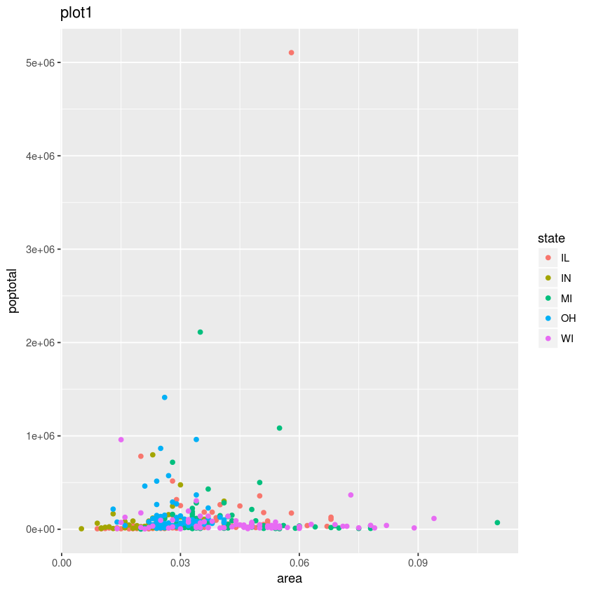

```r
plt1 = ggplot( data=midwest, aes(x=area, y=poptotal, color=state) ) +
    #scatter geometric object (points = observation/county)
    geom_point() + ggtitle("plot1")

plt1
```

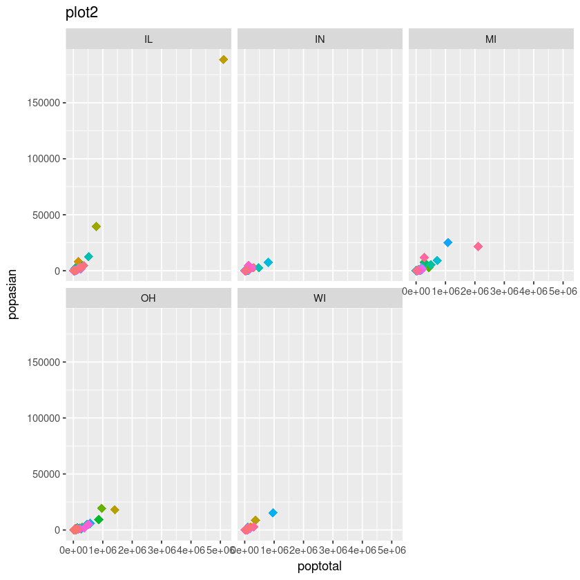

```r
plt2 = ggplot( data=midwest, aes(x=poptotal, y=popasian) ) +
    #scatter geometric object (points = observation/county)
    geom_point( aes(color=county), shape=18, size=3.5, show.legend=FALSE ) + ggtitle("plot2") +
    #subplot dataset by column/variable (state)
        facet_wrap( ~state, scales="fixed", nrow=2 )
        #facet_wrap( ~state, scales="free", nrow=2 )

plt2
```

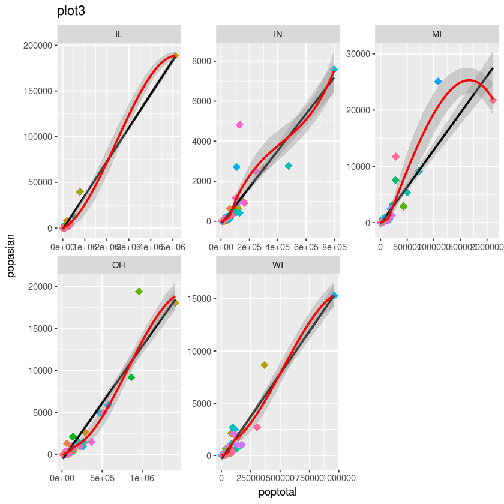

```r
plt3 = plt2 + ggtitle("plot3") +
    facet_wrap( ~state, scales="free", nrow=2 ) +
    #statistical transformation (here groups = facets / local vs global)
        stat_smooth( method = "lm", formula=y~x, size=1, se=T, color="black" ) +
        stat_smooth( aes(group=state), method = "loess", formula=y~x, size=1, se=T, color="red" )

plt3
```

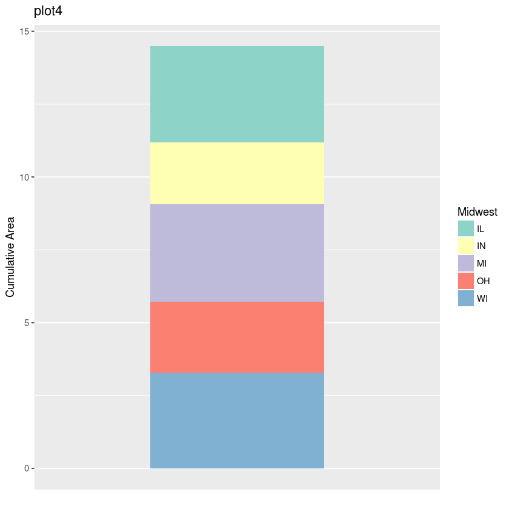

```r
plt4 = ggplot( data=midwest, aes(x=1, y=area, fill=state) ) + ggtitle("plot4") +
    #bar geometric object (stat="identity" - raw data)
    geom_bar( stat="identity", position="stack" ) +
    labs( x="", y="Cumulative Area", fill="Midwest" ) +
    #scale discrete (not continuous) for fill (not color)
        scale_fill_brewer( palette="Set3" ) +
        #scale_fill_manual(values=c("#FFCCFF","#CC99FF","#9933FF", "#330099", "#000033")) +
    scale_x_discrete( breaks="", labels="" )

plt4
```

```r
#print figures to file (pdf / png / svg / etc)
pdf("Figures.pdf", width=40, height=20)
print(plt1)
print(plt2)
print(plt3)
print(plt4)
dev.off()

#?ggsave();#built-in save function
```

**png:** 2

**#Tip 7.** packages often come with tutorials called vignettes.

```r
#CHECK-IN POINT
#EXERCISE - change plt1 so that size of points are now proportional to 'percbelowpoverty', y-axis log10 transformed,
#axis title bold size 10, axis text italics size 8 and major/minor black grid lines.

#EXERCISE - recreate plt4 so that bars are now plotted horizontally per state (unstacked/unfaceted).
```

**Saving / Writing**  
Workspace objects can be saved as *.Rdata/.Rda* files for logged records or future use.  
Results (data, figures, apps) can be outputted as other files also.

```r
ls() #print env objects
```

2. 'colMean'

3. 'datOH'

4. 'datsubAAR'

5. 'df'

6. 'dfOnline'

7. 'i'

8. 'indexOH'

9. 'midwest'

10. 'newdf'

11. 'newdflong'

12. 'plt1'

13. 'plt2'

14. 'plt3'

15. 'plt4'

16. 'rowSE'

17. 'x'

18. 'X'

19. 'y'

```r
rm(plt1,plt2,plt3,plt4) #remove env objects
ls()
```

2. 'colMean'

3. 'datOH'

4. 'datsubAAR'

5. 'df'

6. 'dfOnline'

7. 'i'

8. 'indexOH'

9. 'midwest'

10. 'newdf'

11. 'newdflong'

12. 'rowSE'

13. 'x'

14. 'X'

15. 'y'

```r
save.image("05_29_2019.RData")
#save(list=c("datOH","datminusOH"), file="05_29_2019.RData")

#load("05_29_2019.RData")
```

```r
?write.table
```

```r
write.table(midwest, file="ExampleGGData.csv", sep=",")
#write.table(midwest, file="ExampleGGData.txt", sep="\t")

list.files(path=".", pattern=".csv")

#rm(list=ls());cat("\014")
```

[output not shown]

**Loading / Reading**  
Importing data into *R* from files (.csv/.txt) can range in complexity - multiple options/arguments.  
Examples: separator/delimiter (*",", "\t", " "*), header.

```r
df = read.table(file="ExampleGGData.csv", sep=",")
#df = read.table(file="ExampleGGData.txt", sep="\t")
head(df)

#?read.csv()
#?read.delim()
```

| PID | county | state | area | poptotal | popdensity | popwhite | popblack | popamerindian | popasian | ⋯ | percollege | percprof | poppovertyknown | percpovertyknown | percbelowpoverty | percchildbelowpovert | percadultpoverty | percelderlypoverty | inmetro | category |
| --- | --- | --- | --- | --- | --- | --- | --- | --- | --- | --- | --- | --- | --- | --- | --- | --- | --- | --- | --- | --- |
| 561 | ADAMS | IL | 0.052 | 66090 | 1270.9615 | 63917 | 1702 | 98 | 249 | ⋯ | 19.63139 | 4.355859 | 63628 | 96.27478 | 13.151443 | 18.01172 | 11.009776 | 12.443812 | 0 | AAR |
| 562 | ALEXANDER | IL | 0.014 | 10626 | 759.0000 | 7054 | 3496 | 19 | 48 | ⋯ | 11.24331 | 2.870315 | 10529 | 99.08714 | 32.244278 | 45.82651 | 27.385647 | 25.228976 | 0 | LHR |
| 563 | BOND | IL | 0.022 | 14991 | 681.4091 | 14477 | 429 | 35 | 16 | ⋯ | 17.03382 | 4.488572 | 14235 | 94.95697 | 12.068844 | 14.03606 | 10.852090 | 12.697410 | 0 | AAR |
| 564 | BOONE | IL | 0.017 | 30806 | 1812.1176 | 29344 | 127 | 46 | 150 | ⋯ | 17.27895 | 4.197800 | 30337 | 98.47757 | 7.209019 | 11.17954 | 5.536013 | 6.217047 | 1 | ALU |
| 565 | BROWN | IL | 0.018 | 5836 | 324.2222 | 5264 | 547 | 14 | 5 | ⋯ | 14.47600 | 3.367680 | 4815 | 82.50514 | 13.520249 | 13.02289 | 11.143211 | 19.200000 | 0 | AAR |
| 566 | BUREAU | IL | 0.050 | 35688 | 713.7600 | 35157 | 50 | 65 | 195 | ⋯ | 18.90462 | 3.275891 | 35107 | 98.37200 | 10.399635 | 14.15882 | 8.179287 | 11.008586 | 0 | AAR |

```r
#https://github.com/fivethirtyeight/data

dfOnline = read.table(file="https://raw.githubusercontent.com/fivethirtyeight/data/master/bachelorette/bachelorette.csv", sep=",", header=TRUE)
head(dfOnline)
```

| SHOW | SEASON | CONTESTANT | ELIMINATION.1 | ELIMINATION.2 | ELIMINATION.3 | ELIMINATION.4 | ELIMINATION.5 | ELIMINATION.6 | ELIMINATION.7 | ⋯ | DATES.1 | DATES.2 | DATES.3 | DATES.4 | DATES.5 | DATES.6 | DATES.7 | DATES.8 | DATES.9 | DATES.10 |
| --- | --- | --- | --- | --- | --- | --- | --- | --- | --- | --- | --- | --- | --- | --- | --- | --- | --- | --- | --- | --- |
| SHOW | SEASON | ID | 1 | 2 | 3 | 4 | 5 | 6 | 7 | ⋯ | 1 | 2 | 3 | 4 | 5 | 6 | 7 | 8 | 9 | 10 |
| Bachelorette | 13 | 13_BRYAN_A | R1 |  |  | R | R |  | R | ⋯ |  |  | D6 | D13 | D1 | D7 | D1 | D1 | D1 | D1 |
| Bachelorette | 13 | 13_PETER_K |  | R |  |  |  | R | R | ⋯ |  | D1 | D6 | D13 | D9 | D7 | D1 | D1 | D1 | D1 |
| Bachelorette | 13 | 13_ERIC_B |  |  | R |  |  | R | R | ⋯ |  | D10 | D8 | D13 | D9 | D1 | D3 | D1 | D1 |  |
| Bachelorette | 13 | 13_DEAN_U |  | R |  | R |  |  | R | ⋯ |  | D8 | D8 | D1 | D9 | D7 | D1 | D1 |  |  |
| Bachelorette | 13 | 13_ADAM_G |  |  |  |  |  |  | ED | ⋯ |  | D10 | D8 | D13 | D9 | D7 | D3 |  |  |  |

**#Tip 8.** try package 'openxlsx' for Excel.

```r
#quit()
```

**Command Line**  
Within a terminal *R* can be interactive (open input) or not/batch (closed execution).

`$ R`  
`$ Rscript Rcode.R`  
`$ R CMD BATCH Rcode.R`

*References*  
Software Carpentry: Our Lessons (https://software-carpentry.org/lessons)  
R Packages: Organize, test, document and share your code (https://r-pkgs.org)  
Tidyverse: R packages for data science (https://www.tidyverse.org)  
RStudio: Cheat Sheets (https://www.rstudio.com/resources/cheatsheets)

**Introduction: R and Jupyter**